# Concentration Response Analysis

Zachery Moore

22 October 2026

# 1 Objective

The `dosefitr` package provides tools for analysing dose-response curves and the subsequent calculation of GR, NDR and LGR metrics. This vignette walks through the main functionality of this using an example dataset included with the package.

First, load the package.

```r
library(dosefitr)
```

# 2 Dose-response analysis

The `conc_data` dataset contains spheroid area measurements over time across a range of drug concentrations. As before, we start by plotting the raw data.

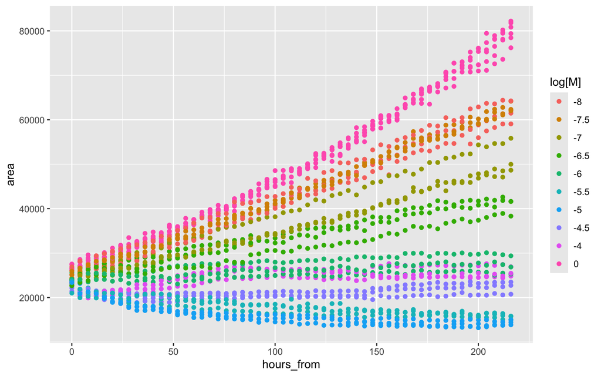

```r
data("conc_data", package = "dosefitr")

ggplot2::ggplot(
  conc_data,
  ggplot2::aes(hours_from, area, colour = as.factor(concentration))
) +
  ggplot2::geom_point() +
  ggplot2::labs(colour = "log[M]")
```

`fit_concentrations()` fits a curve to each concentration. By default it tries every model in `dosefitr_models` and selects the best fit, but this can be restricted to a subset. For example, to consider only sigmoid models:

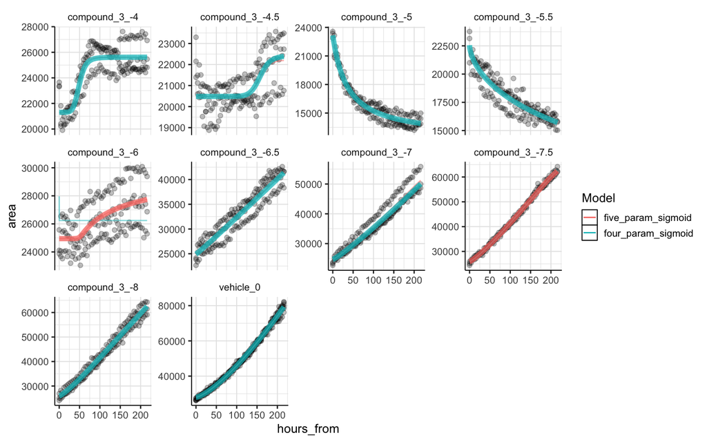

```r
conc_model <- fit_concentrations(
  data = conc_data,
  x_var = "hours_from",
  y_var = "area",
  treatment_column = "treatment_name",
  negative_control_name = "vehicle",
  concentration_column = "concentration",
  outlier_options = list(huber = TRUE, rout = TRUE),
  models = c("four_param_sigmoid", "five_param_sigmoid")
)

conc_model$plot
```

Or to consider all models except `beta_growth_decay`:

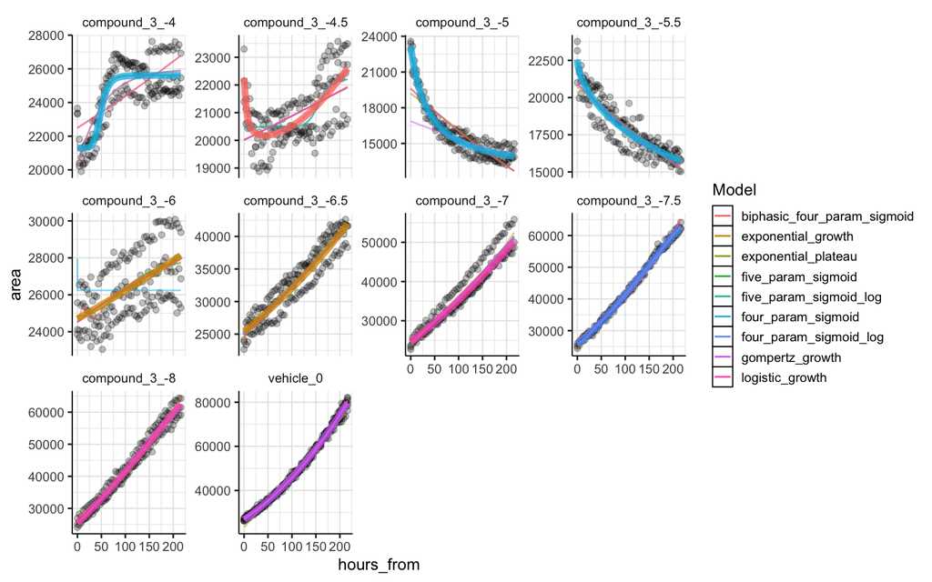

```r
conc_model <- fit_concentrations(
  data = conc_data,
  x_var = "hours_from",
  y_var = "area",
  treatment_column = "treatment_name",
  negative_control_name = "vehicle",
  concentration_column = "concentration",
  outlier_options = list(huber = TRUE, rout = TRUE),
  models = setdiff(names(dosefitr_models), "beta_growth_decay")
)

conc_model$plot
```

## 2.1 Identifying complete killing

The two highest concentrations (-4 and -4.5 log M) clearly break from the trend of the rest of the series. At these doses the spheres were completely killed, so the measured areas are not real signal; they are segmentation artefacts from debris and dead-cell material rather than intact spheres.

This kind of non-monotonic response can be flagged automatically. Setting `monotonic_check = TRUE` warns when the response reverses direction at high concentrations, which is a useful prompt to go back and check the images.

```r
conc_model <- fit_concentrations(
  data = conc_data,
  x_var = "hours_from",
  y_var = "area",
  treatment_column = "treatment_name",
  negative_control_name = "vehicle",
  concentration_column = "concentration",
  outlier_options = list(huber = TRUE, rout = TRUE),
  models = setdiff(names(dosefitr_models), "beta_growth_decay"),
  monotonic_check = TRUE
)
```

```
## These treatment/concentration combination(s) show potential non-monotonic responses. Consider reviewing the data before deciding whether to exclude them:
## compound_3 at -4.5, compound_3 at -4
```

Where you know a concentration caused complete killing, add a logical `exclude` column to the data. Wells marked `TRUE` are treated as 100% killing rather than fitted from their (artefactual) measured areas. If you would rather drop these concentrations from the analysis entirely, filter them out of the data instead.

```r
conc_data <- dplyr::mutate(
  conc_data,
  exclude = concentration %in% c(-4, -4.5)
)

conc_model <- fit_concentrations(
  data = conc_data,
  x_var = "hours_from",
  y_var = "area",
  treatment_column = "treatment_name",
  negative_control_name = "vehicle",
  concentration_column = "concentration",
  outlier_options = list(huber = TRUE, rout = TRUE),
  models = setdiff(names(dosefitr_models), "beta_growth_decay"),
  monotonic_check = TRUE
)
```

## 2.2 Visualising the results

Area over time, coloured by concentration. Concentrations marked as complete killing are shown in red.

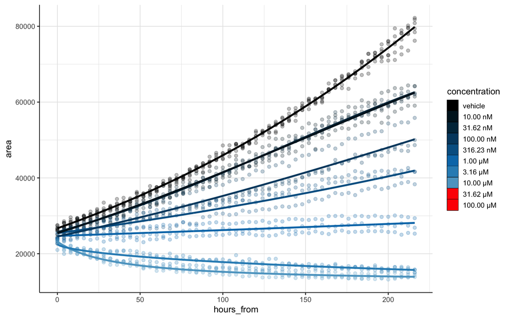

```r
plot_curve_concentration(
  model_list = conc_model$model_list,
  x_var = "hours_from",
  y_var = "area",
  treatment_column = "treatment_name",
  concentration_column = "concentration",
  negative_control_name = "vehicle"
)
```

Growth rate (GR) over time at each concentration shows how the drug alters the rate of growth throughout the experiment.

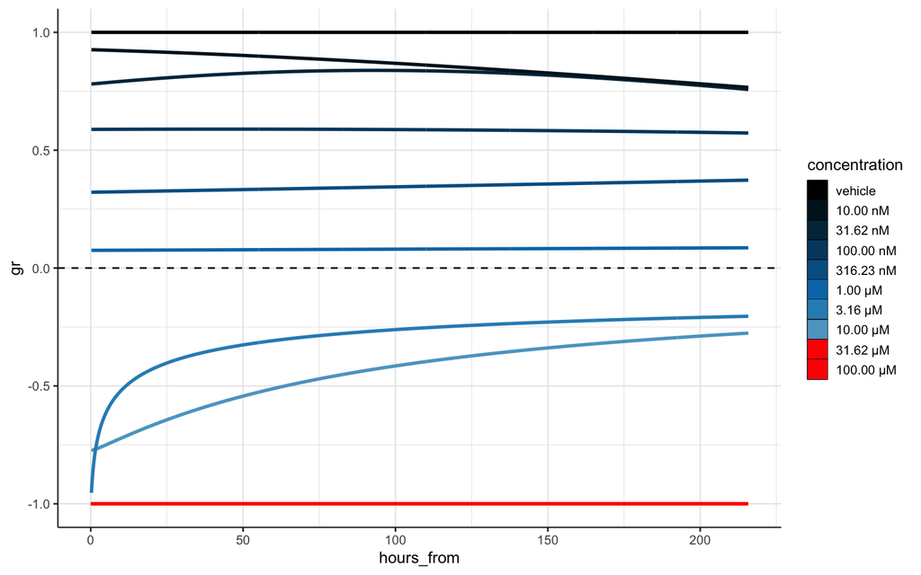

```r
plot_metric_time <- plot_curve_concentration_metric_time(
  model_list = conc_model$model_list,
  x_var = "hours_from",
  metric = "gr",
  treatment_column = "treatment_name",
  concentration_column = "concentration",
  negative_control_name = "vehicle"
)

plot_metric_time$plot
```

Finally, the dose-response curve summarises growth inhibition as a function of drug concentration, incorporating GR values measured at all timepoints across the experiment.

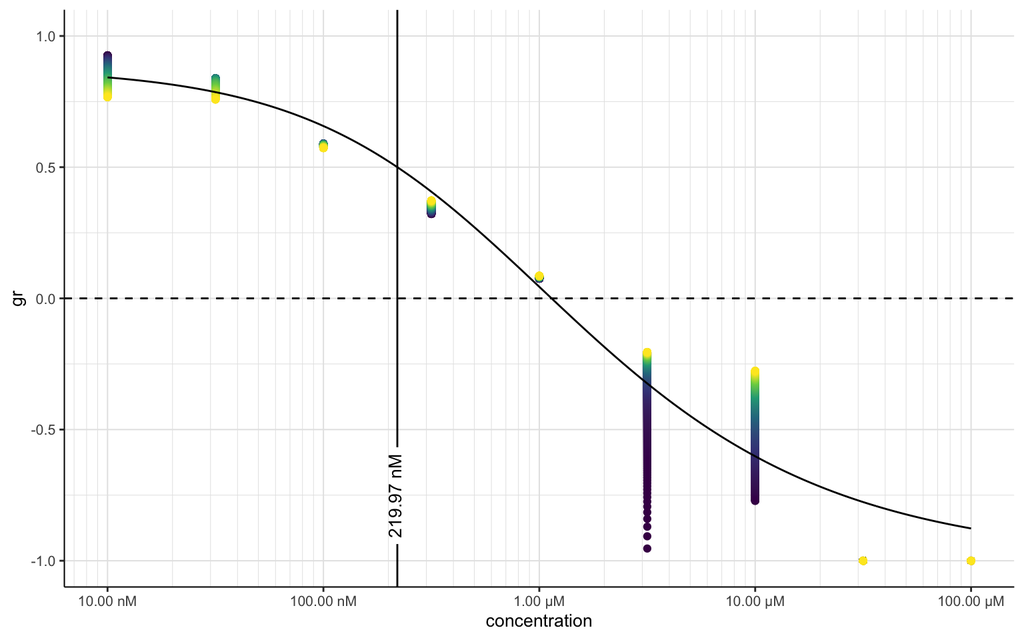

```r
plot_metric_dose <- plot_curve_concentration_metric_dose(
  model_list = conc_model$model_list,
  x_var = "hours_from",
  metric = "gr",
  treatment_column = "treatment_name",
  concentration_column = "concentration",
  negative_control_name = "vehicle"
)

plot_metric_dose$plot
```

We can also use the LGR score to visualise response. See the `dosefitr` manuscript on a full explanation of this metric and it’s interpretation.

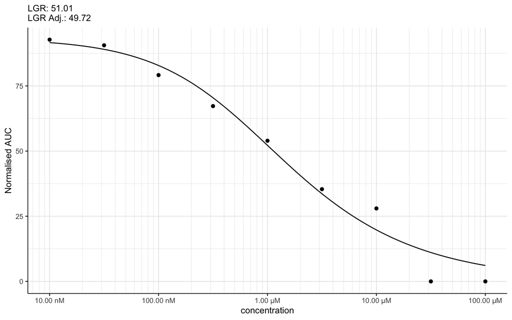

```r
plot_lgr_score(
  model_list = conc_model$model_list,
  x_var = "hours_from",
  metric = "gr",
  treatment_column = "treatment_name",
  concentration_column = "concentration",
  negative_control_name = "vehicle"
)
```